# Proyecto Final - Efecto del Clima y Factores Ambientales en la Productividad Agrícola

Est. Apl. 2

## Introducción al Problema

La productividad agrícola es fundamental para la seguridad alimentaria y el desarrollo económico de muchas regiones del mundo. El cambio climático y las fluctuaciones ambientales han generado preocupaciones sobre cómo estos factores influyen en el rendimiento de los cultivos y, en consecuencia, en la sostenibilidad de la agricultura a nivel global.

Este análisis busca comprender el efecto que las condiciones climáticas y los factores ambientales tienen sobre la productividad agrícola. La relevancia de este problema radica en su impacto directo sobre la capacidad de los países para satisfacer las demandas alimenticias de su población, especialmente en un contexto de cambio climático y creciente presión sobre los recursos naturales.

A partir de este contexto, se plantea responder a las siguientes preguntas de investigación mediante un análisis estadístico:  
1. ¿Qué factores ambientales tienen un efecto significativo en la productividad agrícola? 2. ¿Qué modelo estadístico ofrece la mejor predicción de la productividad?

El objetivo de este análisis es aportar información que pueda ser útil para diseñar políticas y estrategias agrícolas más resilientes y sostenibles en el futuro.

## Análisis de Datos

El conjunto de datos utilizado en este análisis proviene de Kaggle y está disponible en el siguiente enlace: [Global Agriculture Climate Impact Dataset](https://www.kaggle.com/datasets/talhachoudary/global-agriculture-climate-impact-dataset?resource=download). Este dataset ofrece información detallada sobre la interacción entre factores climáticos, ambientales y agrícolas, y su impacto en la productividad de los cultivos. A continuación, se describen las variables incluidas en el dataset:

- **`Crop_Yield_MT_per_HA`**
  - **Tipo**: Numérica continua
  - **Descripción**: Productividad agrícola medida en toneladas métricas por hectárea. Esta es la variable objetivo del análisis.
- **`Year`**
  - **Tipo**: Numérica entera
  - **Descripción**: Año en que se registraron los datos, util para análisis temporales y de tendencias.
- **`Country`**
  - **Tipo**: Categórica
  - **Descripción**: País donde se recopiló la información, permite comparaciones entre regiones globales.
- **`Region`**
  - **Tipo**: Categórica
  - **Descripción**: Región específica dentro del país, utilizada para un análisis más granular.
- **`Crop_Type`**
  - **Tipo**: Categórica
  - **Descripción**: Tipo de cultivo analizado (e.g., trigo, maíz, arroz), relevante para estudiar el impacto de los factores en distintos cultivos.
- **`Average_Temperature_C`**
  - **Tipo**: Numérica continua
  - **Descripción**: Temperatura promedio registrada durante la temporada de cultivo, clave para evaluar el efecto del clima en el rendimiento agrícola.
- **`Total_Precipitation_mm`**
  - **Tipo**: Numérica continua
  - **Descripción**: Precipitación total (en milímetros) durante la temporada de cultivo, esencial para analizar la influencia de la lluvia en los cultivos.
- **`CO2_Emissions_MT`**
  - **Tipo**: Numérica continua
  - **Descripción**: Emisiones de CO2 (en toneladas métricas) relacionadas con actividades agrícolas o de la región.
- **`Extreme_Weather_Events`**
  - **Tipo**: Numérica entera
  - **Descripción**: Numero de eventos climáticos extremos (e.g., sequías, inundaciones) durante la temporada.
- **`Irrigation_Access_%`**
  - **Tipo**: Numérica continua
  - **Descripción**: Porcentaje del área de cultivo que cuenta con acceso a sistemas de riego, indicador clave de infraestructura agrícola.
- **`Pesticide_Use_KG_per_HA`**
  - **Tipo**: Numérica continua
  - **Descripción**: Uso de pesticidas en kilogramos por hectárea, relacionado con el manejo de plagas y enfermedades en los cultivos.
- **`Fertilizer_Use_KG_per_HA`**
  - **Tipo**: Numérica continua
  - **Descripción**: Cantidad de fertilizantes utilizados por hectárea, esencial para estudiar la fertilidad del suelo y la productividad.
- **`Soil_Health_Index`**
  - **Tipo**: Numérica continua
  - **Descripción**: Índice que evalua la calidad y salud del suelo, un factor importante en el rendimiento agrícola sostenible.
- **`Adaptation_Strategies`**
  - **Tipo**: Categórica
  - **Descripción**: Estrategias adoptadas para mitigar o adaptarse a los efectos del clima (e.g., rotación de cultivos, manejo de agua).
- **`Economic_Impact_Million_USD`**
  - **Tipo**: Numérica continua
  - **Descripción**: Impacto económico estimado en millones de dólares, util para evaluar las implicaciones económicas de los factores climáticos.

Este dataset proporciona una base rica para explorar las relaciones entre los factores ambientales y climáticos, y la productividad agrícola a nivel global.

Cargamos ahora los datos y pasamos **`Crop_Yield_MT_per_HA`** como la primer columna

```r
file_path <- "Data/climate_change_impact_on_agriculture_2024.csv"
## Data obtained from https://www.kaggle.com/datasets/talhachoudary/global-agriculture-climate-impact-dataset
climate_data <- read.csv(file_path)
climate_data <- climate_data[, c("Crop_Yield_MT_per_HA", setdiff(names(climate_data), "Crop_Yield_MT_per_HA"))]
```

### Variables Numéricas: Boxplots e histogramas

Los siguientes boxplots muestran la distribución de las variables numéricas en el dataset.

Cargamos librerías

```r
if (!require("tidyverse")) install.packages("tidyverse")
if (!require("effectsize")) install.packages("effectsize") # Para calcular eta squared
if (!require("knitr")) install.packages("knitr")
library(knitr)
library(tidyverse)
library(effectsize)
```

Boxplot e histograma de `Crop_Yield_MT_per_HA`

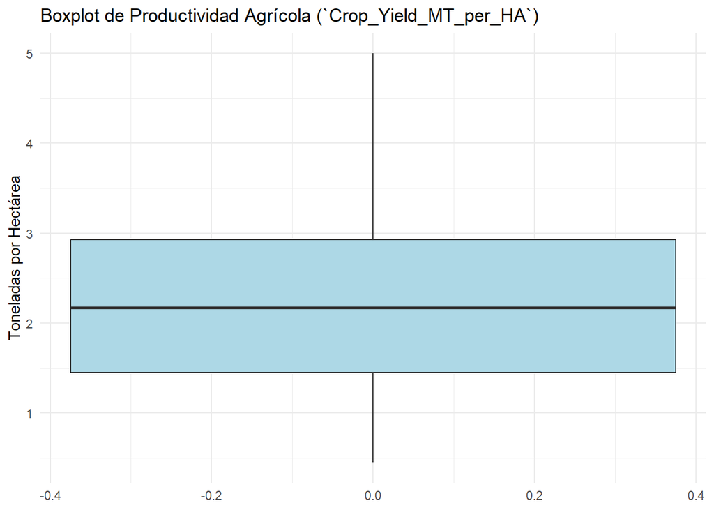

```r
ggplot(climate_data, aes(y = Crop_Yield_MT_per_HA)) +
  geom_boxplot(outlier.color = "red", fill = "lightblue") +
  theme_minimal() +
  labs(
    title = "Boxplot de Productividad Agrícola (`Crop_Yield_MT_per_HA`)",
    y = "Toneladas por Hectárea"
  )
```

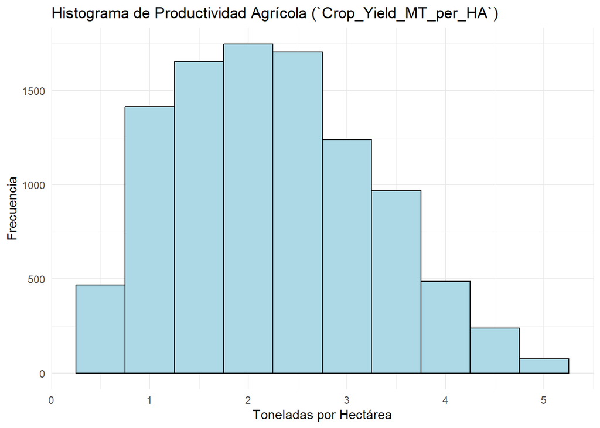

```r
ggplot(climate_data, aes(x = Crop_Yield_MT_per_HA)) +
  geom_histogram(binwidth = 0.5, fill = "lightblue", color = "black") +
  theme_minimal() +
  labs(
    title = "Histograma de Productividad Agrícola (`Crop_Yield_MT_per_HA`)",
    x = "Toneladas por Hectárea",
    y = "Frecuencia"
  )
```

Boxplot e histograma de `Year`

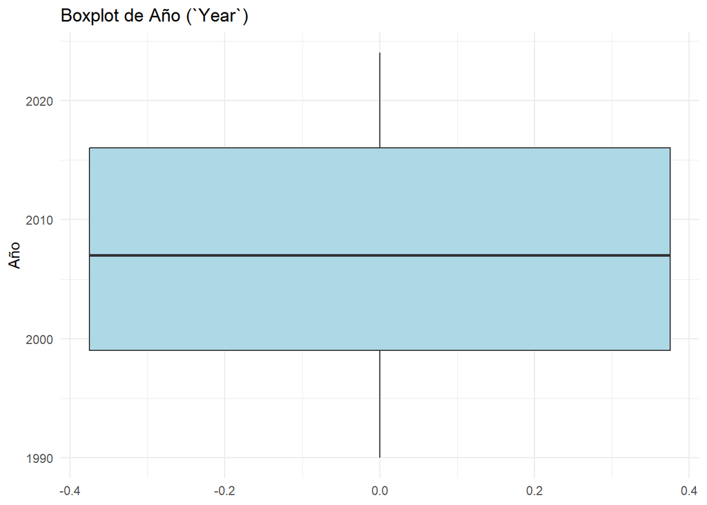

```r
ggplot(climate_data, aes(y = Year)) +
  geom_boxplot(outlier.color = "red", fill = "lightblue") +
  theme_minimal() +
  labs(
    title = "Boxplot de Año (`Year`)",
    y = "Año"
  )
```

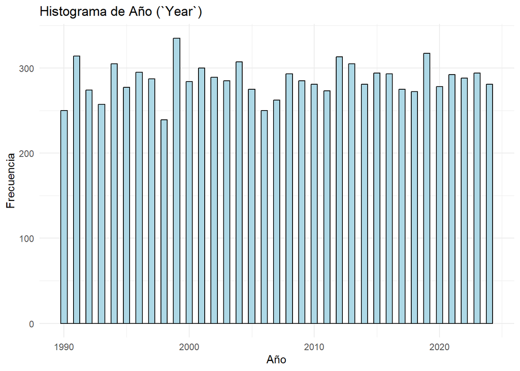

```r
ggplot(climate_data, aes(x = Year)) +
  geom_histogram(binwidth = 0.5, fill = "lightblue", color = "black") +
  theme_minimal() +
  labs(
    title = "Histograma de Año (`Year`)",
    x = "Año",
    y = "Frecuencia"
  )
```

Boxplot e histograma de `Average_Temperature_C`

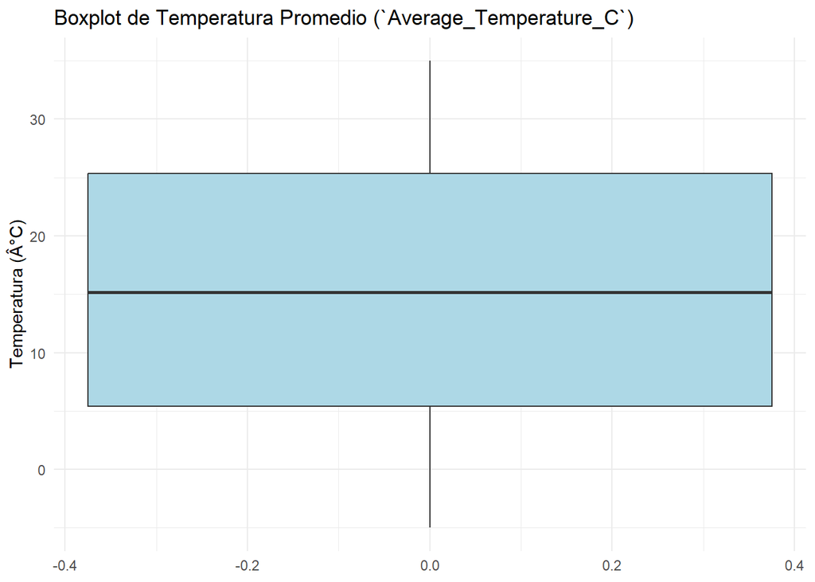

```r
ggplot(climate_data, aes(y = Average_Temperature_C)) +
  geom_boxplot(outlier.color = "red", fill = "lightblue") +
  theme_minimal() +
  labs(
    title = "Boxplot de Temperatura Promedio (`Average_Temperature_C`)",
    y = "Temperatura (Â°C)"
  )
```

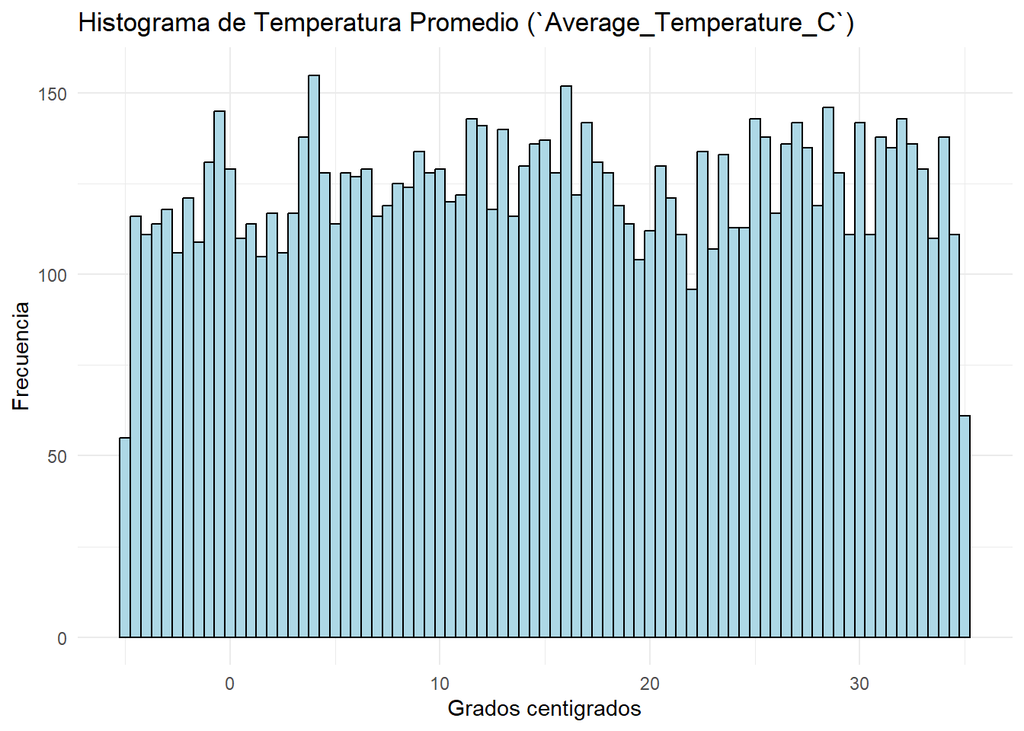

```r
ggplot(climate_data, aes(x = Average_Temperature_C)) +
  geom_histogram(binwidth = 0.5, fill = "lightblue", color = "black") +
  theme_minimal() +
  labs(
    title = "Histograma de Temperatura Promedio (`Average_Temperature_C`)",
    x = "Grados centigrados",
    y = "Frecuencia"
  )
```

Boxplot e historgama de `Total_Precipitation_mm`

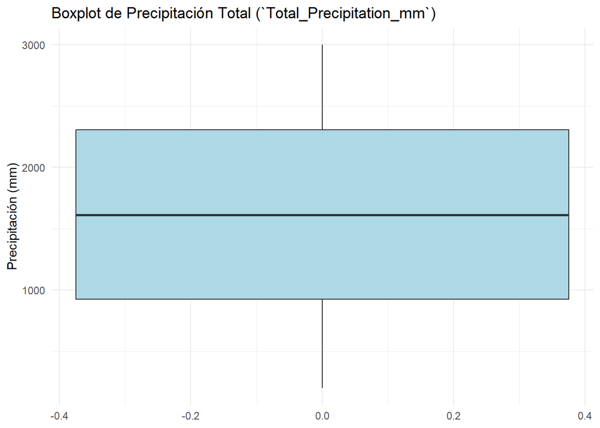

```r
ggplot(climate_data, aes(y = Total_Precipitation_mm)) +
  geom_boxplot(outlier.color = "red", fill = "lightblue") +
  theme_minimal() +
  labs(
    title = "Boxplot de Precipitación Total (`Total_Precipitation_mm`)",
    y = "Precipitación (mm)"
  )
```

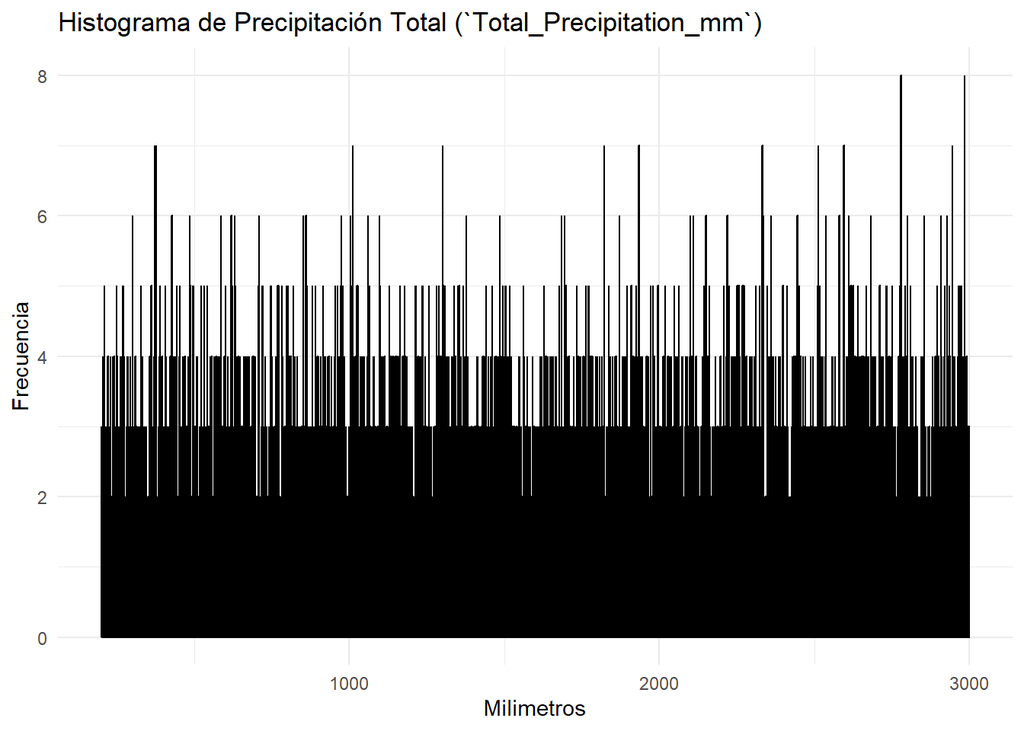

```r
ggplot(climate_data, aes(x = Total_Precipitation_mm)) +
  geom_histogram(binwidth = 0.5, fill = "lightblue", color = "black") +
  theme_minimal() +
  labs(
    title = "Histograma de Precipitación Total (`Total_Precipitation_mm`)",
    x = "Milimetros",
    y = "Frecuencia"
  )
```

Boxplot e histograma de `CO2_Emissions_MT`

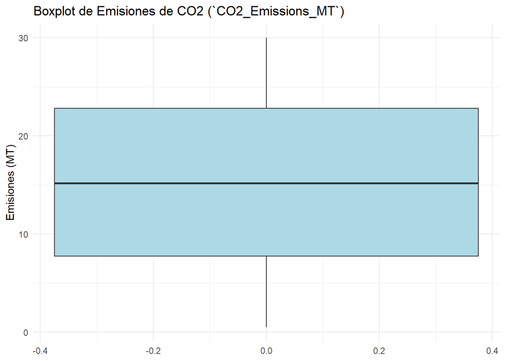

```r
ggplot(climate_data, aes(y = CO2_Emissions_MT)) +
  geom_boxplot(outlier.color = "red", fill = "lightblue") +
  theme_minimal() +
  labs(
    title = "Boxplot de Emisiones de CO2 (`CO2_Emissions_MT`)",
    y = "Emisiones (MT)"
  )
```

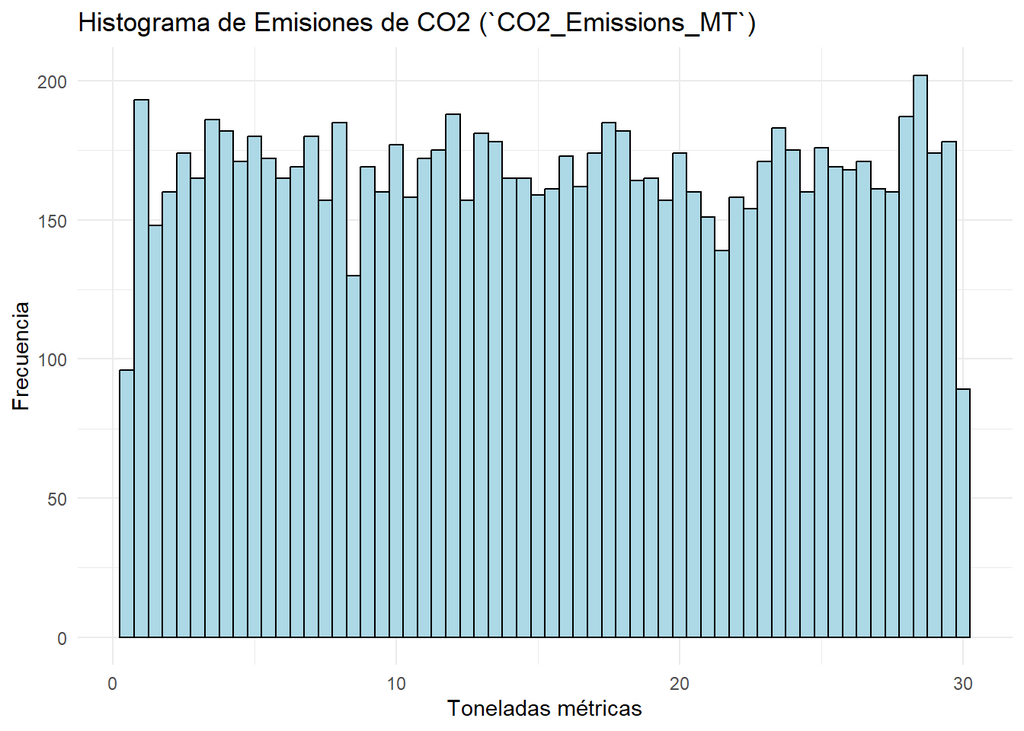

```r
ggplot(climate_data, aes(x = CO2_Emissions_MT)) +
  geom_histogram(binwidth = 0.5, fill = "lightblue", color = "black") +
  theme_minimal() +
  labs(
    title = "Histograma de Emisiones de CO2 (`CO2_Emissions_MT`)",
    x = "Toneladas métricas",
    y = "Frecuencia"
  )
```

Boxplot e histograma de `Extreme_Weather_Events`

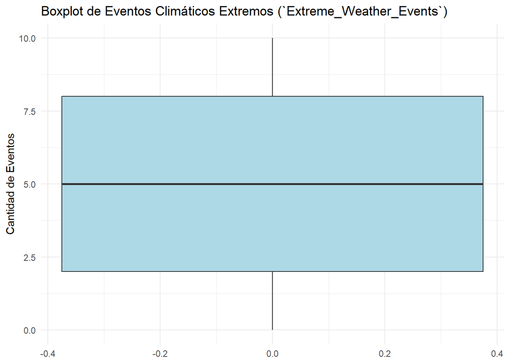

```r
ggplot(climate_data, aes(y = Extreme_Weather_Events)) +
  geom_boxplot(outlier.color = "red", fill = "lightblue") +
  theme_minimal() +
  labs(
    title = "Boxplot de Eventos Climáticos Extremos (`Extreme_Weather_Events`)",
    y = "Cantidad de Eventos"
  )
```

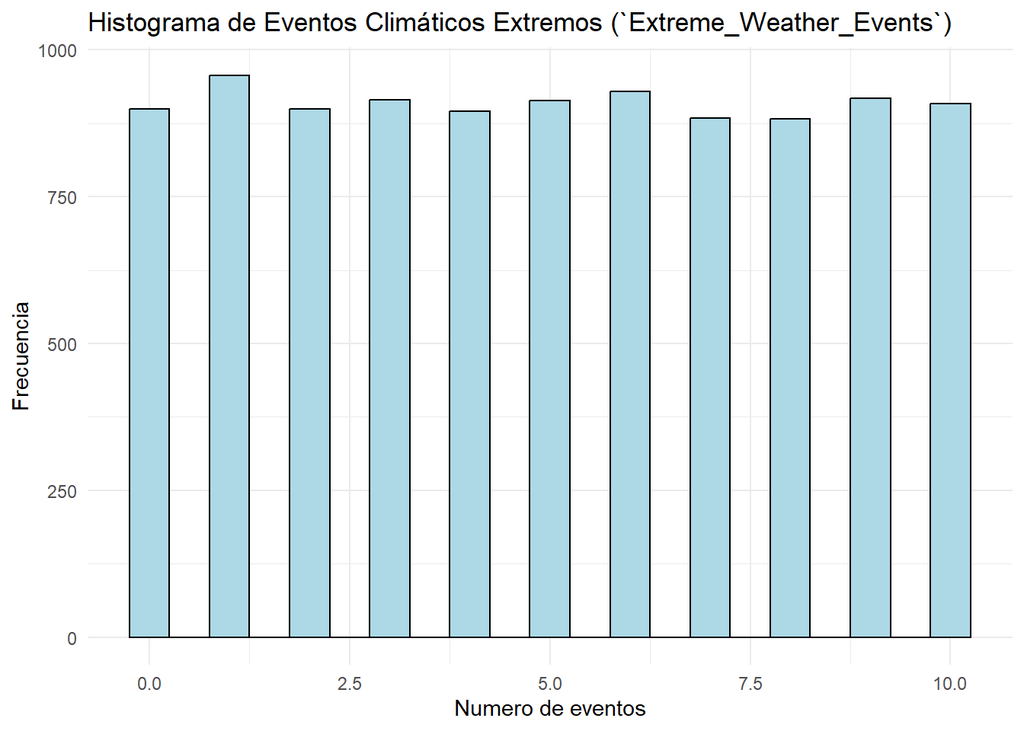

```r
ggplot(climate_data, aes(x = Extreme_Weather_Events)) +
  geom_histogram(binwidth = 0.5, fill = "lightblue", color = "black") +
  theme_minimal() +
  labs(
    title = "Histograma de Eventos Climáticos Extremos (`Extreme_Weather_Events`)",
    x = "Numero de eventos",
    y = "Frecuencia"
  )
```

Boxplot e histograma de `Irrigation_Access_%`

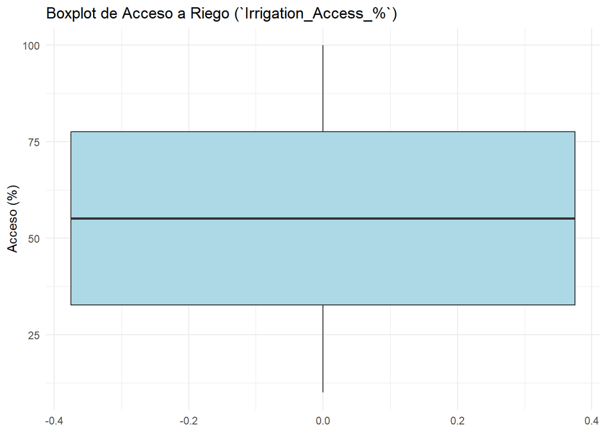

```r
ggplot(climate_data, aes(y = Irrigation_Access_.)) +
  geom_boxplot(outlier.color = "red", fill = "lightblue") +
  theme_minimal() +
  labs(
    title = "Boxplot de Acceso a Riego (`Irrigation_Access_%`)",
    y = "Acceso (%)"
  )
```

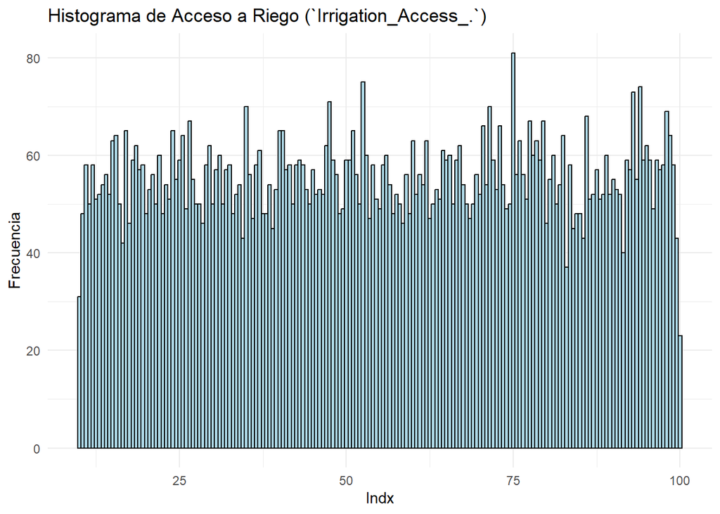

```r
ggplot(climate_data, aes(x = Irrigation_Access_.)) +
  geom_histogram(binwidth = 0.5, fill = "lightblue", color = "black") +
  theme_minimal() +
  labs(
    title = "Histograma de Acceso a Riego (`Irrigation_Access_.`)",
    x = "Indx",
    y = "Frecuencia"
  )
```

Boxplot e histograma de `Pesticide_Use_KG_per_HA`

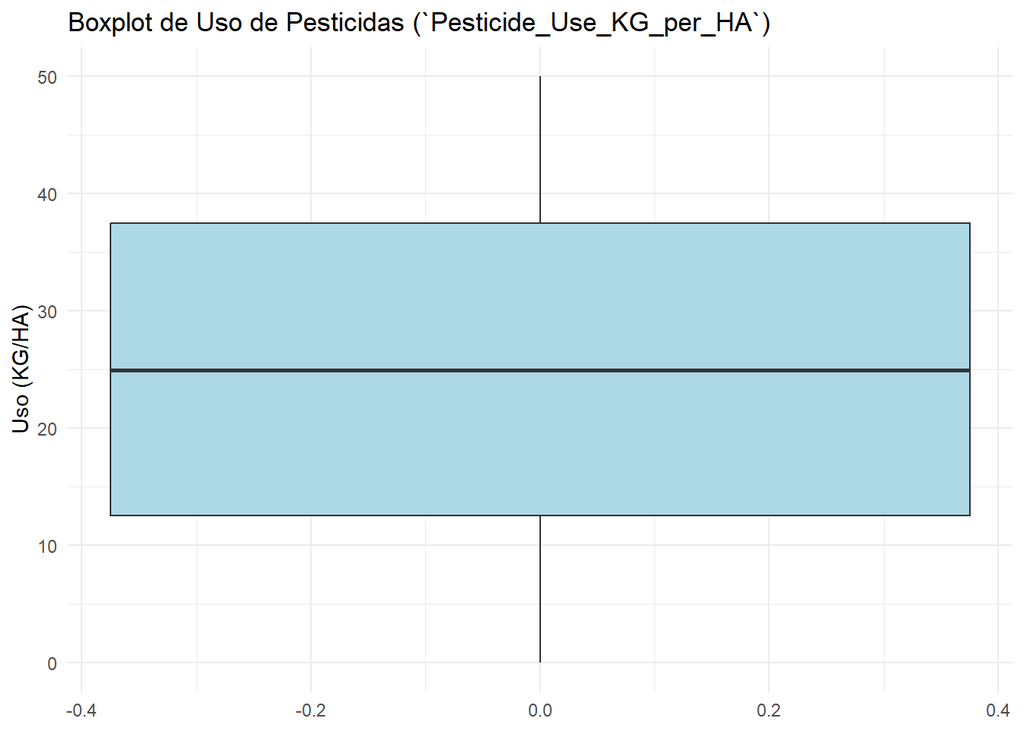

```r
ggplot(climate_data, aes(y = Pesticide_Use_KG_per_HA)) +
  geom_boxplot(outlier.color = "red", fill = "lightblue") +
  theme_minimal() +
  labs(
    title = "Boxplot de Uso de Pesticidas (`Pesticide_Use_KG_per_HA`)",
    y = "Uso (KG/HA)"
  )
```

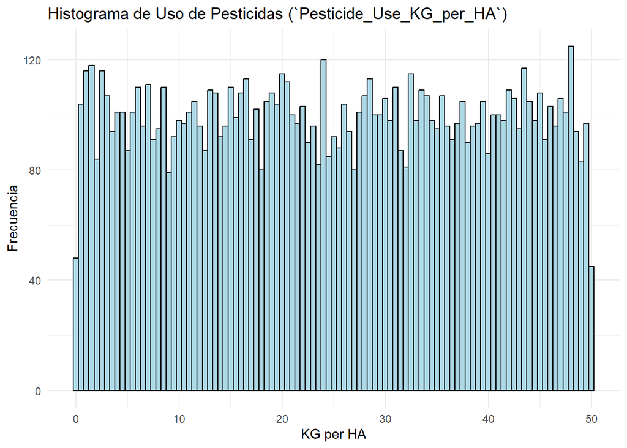

```r
ggplot(climate_data, aes(x = Pesticide_Use_KG_per_HA)) +
  geom_histogram(binwidth = 0.5, fill = "lightblue", color = "black") +
  theme_minimal() +
  labs(
    title = "Histograma de Uso de Pesticidas (`Pesticide_Use_KG_per_HA`)",
    x = "KG per HA",
    y = "Frecuencia"
  )
```

Boxplot e histograma de `Fertilizer_Use_KG_per_HA`

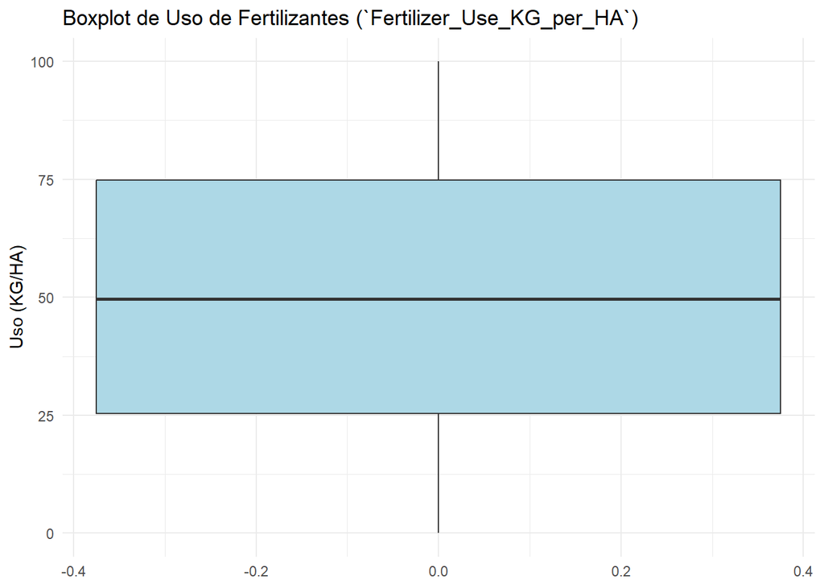

```r
ggplot(climate_data, aes(y = Fertilizer_Use_KG_per_HA)) +
  geom_boxplot(outlier.color = "red", fill = "lightblue") +
  theme_minimal() +
  labs(
    title = "Boxplot de Uso de Fertilizantes (`Fertilizer_Use_KG_per_HA`)",
    y = "Uso (KG/HA)"
  )
```

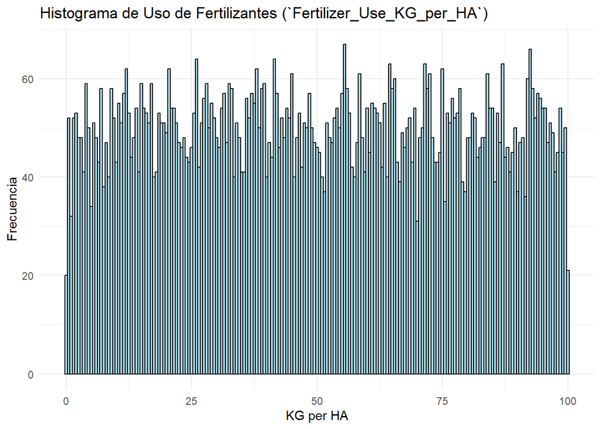

```r
ggplot(climate_data, aes(x = Fertilizer_Use_KG_per_HA)) +
  geom_histogram(binwidth = 0.5, fill = "lightblue", color = "black") +
  theme_minimal() +
  labs(
    title = "Histograma de Uso de Fertilizantes (`Fertilizer_Use_KG_per_HA`)",
    x = "KG per HA",
    y = "Frecuencia"
  )
```

Boxplot e histograma de `Soil_Health_Index`

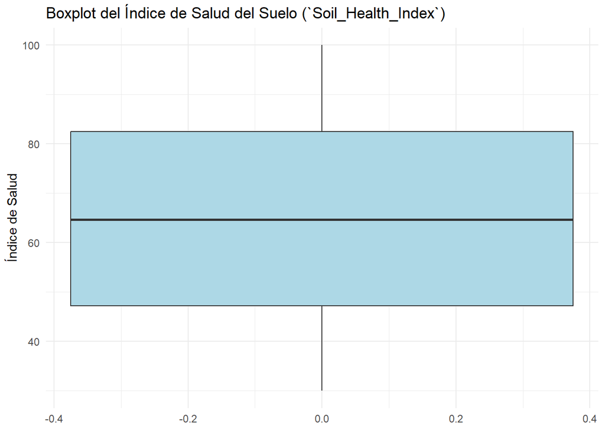

```r
ggplot(climate_data, aes(y = Soil_Health_Index)) +
  geom_boxplot(outlier.color = "red", fill = "lightblue") +
  theme_minimal() +
  labs(
    title = "Boxplot del Índice de Salud del Suelo (`Soil_Health_Index`)",
    y = "Índice de Salud"
  )
```

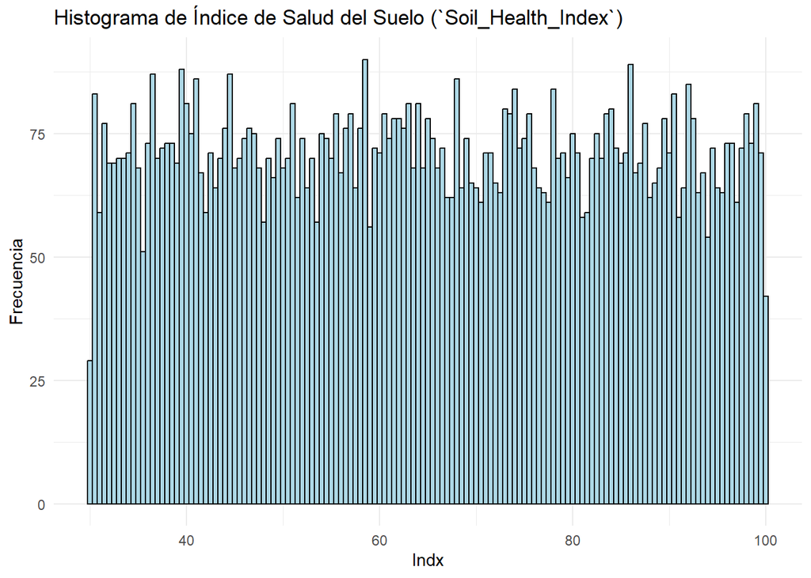

```r
ggplot(climate_data, aes(x = Soil_Health_Index)) +
  geom_histogram(binwidth = 0.5, fill = "lightblue", color = "black") +
  theme_minimal() +
  labs(
    title = "Histograma de Índice de Salud del Suelo (`Soil_Health_Index`)",
    x = "Indx",
    y = "Frecuencia"
  )
```

Boxplot e histograma de `Economic_Impact_Million_USD`

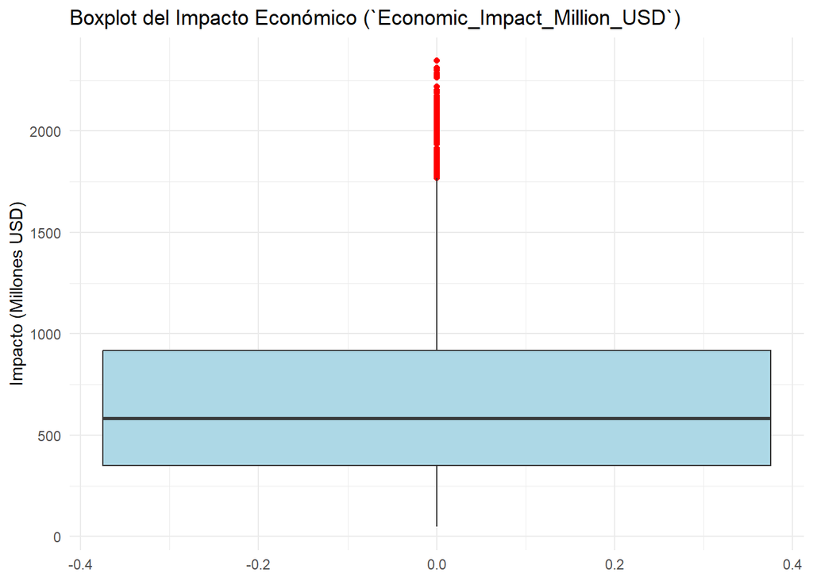

```r
ggplot(climate_data, aes(y = Economic_Impact_Million_USD)) +
  geom_boxplot(outlier.color = "red", fill = "lightblue") +
  theme_minimal() +
  labs(
    title = "Boxplot del Impacto Económico (`Economic_Impact_Million_USD`)",
    y = "Impacto (Millones USD)"
  )
```

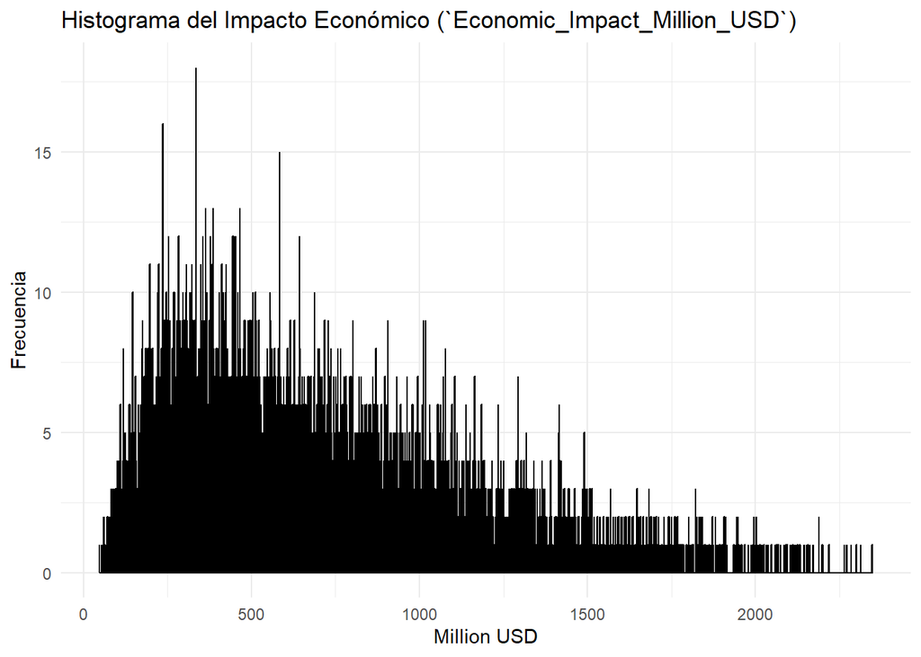

```r
ggplot(climate_data, aes(x = Economic_Impact_Million_USD)) +
  geom_histogram(binwidth = 0.5, fill = "lightblue", color = "black") +
  theme_minimal() +
  labs(
    title = "Histograma del Impacto Económico (`Economic_Impact_Million_USD`)",
    x = "Million USD",
    y = "Frecuencia"
  )
```

### Variables Categóricas: Tablas de Frecuencia

A continuación, se presentan las tablas de frecuencia para las variables categóricas del dataset.

Frecuencia de Países **`Country`**

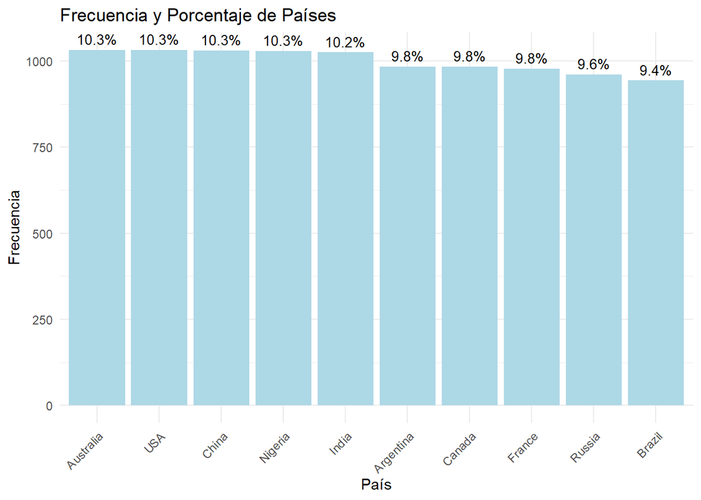

```r
# Crear la tabla de frecuencias y calcular el porcentaje
var_freq <- as.data.frame(table(climate_data$Country))
colnames(var_freq) <- c("Country", "Frequency")
var_freq <- var_freq %>%
  mutate(Percentage = (Frequency / sum(Frequency)) * 100)

# Crear la gráfica combinada de frecuencia y porcentaje
ggplot(var_freq, aes(x = reorder(Country, -Frequency), y = Frequency)) +
  geom_bar(stat = "identity", fill = "lightblue") +
  geom_text(aes(label = paste0(round(Percentage, 1), "%")),
            vjust = -0.5, size = 3.5, color = "black") +
  theme_minimal() +
  labs(
    title = "Frecuencia y Porcentaje de Países",
    x = "País",
    y = "Frecuencia"
  ) +
  theme(axis.text.x = element_text(angle = 45, hjust = 1))
```

Frecuencia de Regiones **`Region`**

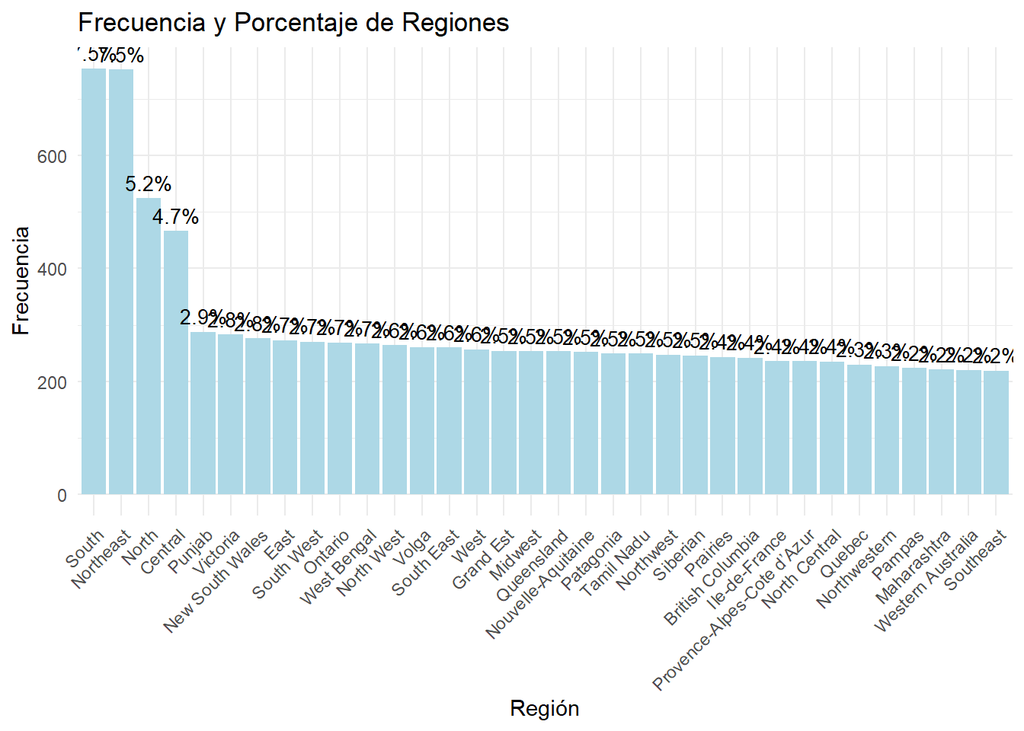

```r
# Crear la tabla de frecuencias y calcular el porcentaje
var_freq <- as.data.frame(table(climate_data$Region))
colnames(var_freq) <- c("Region", "Frequency")
var_freq <- var_freq %>%
  mutate(Percentage = (Frequency / sum(Frequency)) * 100)

# Crear la gráfica combinada de frecuencia y porcentaje
ggplot(var_freq, aes(x = reorder(Region, -Frequency), y = Frequency)) +
  geom_bar(stat = "identity", fill = "lightblue") +
  geom_text(aes(label = paste0(round(Percentage, 1), "%")),
            vjust = -0.5, size = 3.5, color = "black") +
  theme_minimal() +
  labs(
    title = "Frecuencia y Porcentaje de Regiones",
    x = "Región",
    y = "Frecuencia"
  ) +
  theme(axis.text.x = element_text(angle = 45, hjust = 1))
```

Frecuencia de Tipos de Cultivo **`Crop_Type`**

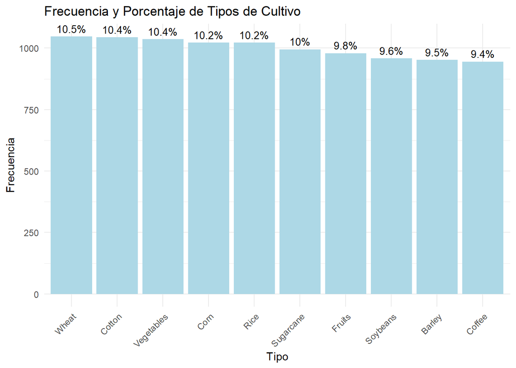

```r
# Crear la tabla de frecuencias y calcular el porcentaje
var_freq <- as.data.frame(table(climate_data$Crop_Type))
colnames(var_freq) <- c("Crop_Type", "Frequency")
var_freq <- var_freq %>%
  mutate(Percentage = (Frequency / sum(Frequency)) * 100)

# Crear la gráfica combinada de frecuencia y porcentaje
ggplot(var_freq, aes(x = reorder(Crop_Type, -Frequency), y = Frequency)) +
  geom_bar(stat = "identity", fill = "lightblue") +
  geom_text(aes(label = paste0(round(Percentage, 1), "%")),
            vjust = -0.5, size = 3.5, color = "black") +
  theme_minimal() +
  labs(
    title = "Frecuencia y Porcentaje de Tipos de Cultivo",
    x = "Tipo",
    y = "Frecuencia"
  ) +
  theme(axis.text.x = element_text(angle = 45, hjust = 1))
```

Frecuencia de Estrategias de Adaptación **`Adaptation_Strategies`**

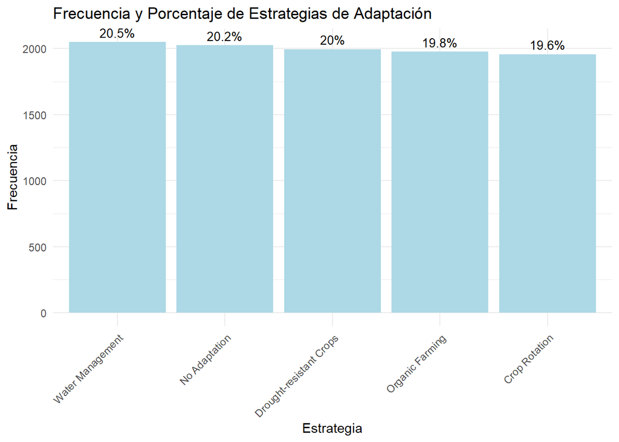

```r
# Crear la tabla de frecuencias y calcular el porcentaje
var_freq <- as.data.frame(table(climate_data$Adaptation_Strategies))
colnames(var_freq) <- c("Adaptation_Strategies", "Frequency")
var_freq <- var_freq %>%
  mutate(Percentage = (Frequency / sum(Frequency)) * 100)

# Crear la gráfica combinada de frecuencia y porcentaje
ggplot(var_freq, aes(x = reorder(Adaptation_Strategies, -Frequency), y = Frequency)) +
  geom_bar(stat = "identity", fill = "lightblue") +
  geom_text(aes(label = paste0(round(Percentage, 1), "%")),
            vjust = -0.5, size = 3.5, color = "black") +
  theme_minimal() +
  labs(
    title = "Frecuencia y Porcentaje de Estrategias de Adaptación",
    x = "Estrategia",
    y = "Frecuencia"
  ) +
  theme(axis.text.x = element_text(angle = 45, hjust = 1))
```

### Pairwise scatter plots

Obtengamos la información numérica

```r
numeric_vars <- climate_data[, sapply(climate_data, is.numeric)]
```

Hagamos el plot

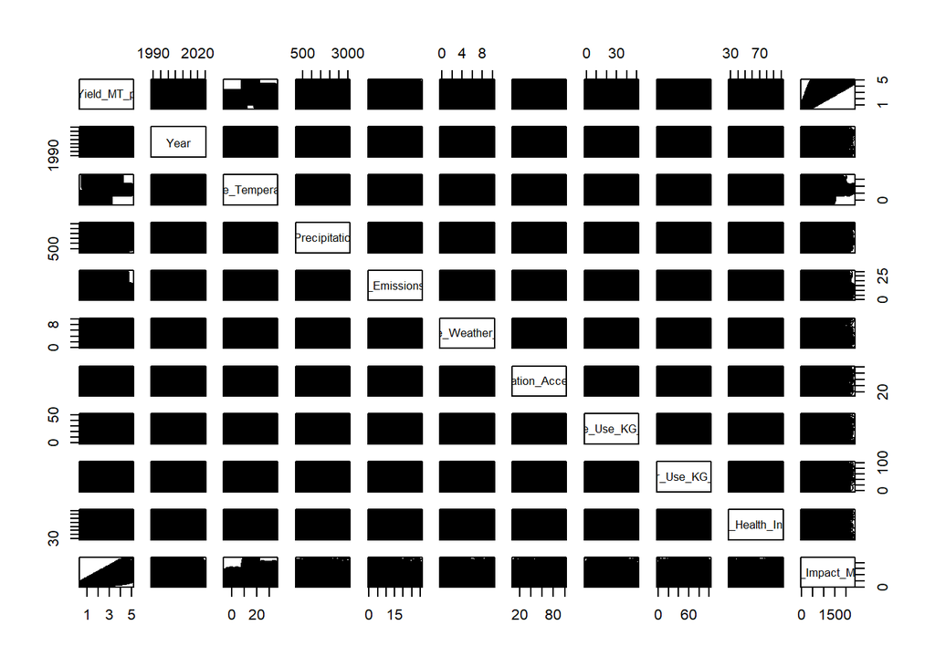

```r
pairs(numeric_vars)
```

### Coeficientes empíricos de Pearson

Veamos qué tan correlacionadas están nuestras variables utilizando el coeficiente empírico de Pearson

```r
cor(numeric_vars)
```

```
##                             Crop_Yield_MT_per_HA          Year
## Crop_Yield_MT_per_HA                1.0000000000  0.0107343120
## Year                                0.0107343120  1.0000000000
## Average_Temperature_C               0.2637807247 -0.0045832797
## Total_Precipitation_mm              0.0297275124  0.0065507704
## CO2_Emissions_MT                   -0.0898682261 -0.0054607502
## Extreme_Weather_Events             -0.0050936865 -0.0027256110
## Irrigation_Access_.                -0.0002552148  0.0009382541
## Pesticide_Use_KG_per_HA            -0.0040349741 -0.0043321234
## Fertilizer_Use_KG_per_HA            0.0064225955  0.0131323385
## Soil_Health_Index                  -0.0056924480 -0.0062943588
## Economic_Impact_Million_USD         0.7263578607  0.0124190431
##                             Average_Temperature_C Total_Precipitation_mm
## Crop_Yield_MT_per_HA                  0.263780725            0.029727512
## Year                                 -0.004583280            0.006550770
## Average_Temperature_C                 1.000000000            0.007212992
## Total_Precipitation_mm                0.007212992            1.000000000
## CO2_Emissions_MT                     -0.003052258           -0.008680624
## Extreme_Weather_Events               -0.016808367            0.004359964
## Irrigation_Access_.                  -0.013268488           -0.007580407
## Pesticide_Use_KG_per_HA               0.005763810            0.011197612
## Fertilizer_Use_KG_per_HA             -0.014725266           -0.026355762
## Soil_Health_Index                    -0.010841039           -0.021620639
## Economic_Impact_Million_USD           0.195827178            0.020965643
##                             CO2_Emissions_MT Extreme_Weather_Events
## Crop_Yield_MT_per_HA            -0.089868226           -0.005093687
## Year                            -0.005460750           -0.002725611
## Average_Temperature_C           -0.003052258           -0.016808367
## Total_Precipitation_mm          -0.008680624            0.004359964
## CO2_Emissions_MT                 1.000000000            0.001254966
## Extreme_Weather_Events           0.001254966            1.000000000
## Irrigation_Access_.              0.002995367           -0.012050822
## Pesticide_Use_KG_per_HA          0.015242534            0.010497230
## Fertilizer_Use_KG_per_HA        -0.020274987            0.014754099
## Soil_Health_Index                0.004517745            0.016266265
## Economic_Impact_Million_USD     -0.057035161           -0.004525935
##                             Irrigation_Access_. Pesticide_Use_KG_per_HA
## Crop_Yield_MT_per_HA              -0.0002552148            -0.004034974
## Year                               0.0009382541            -0.004332123
## Average_Temperature_C             -0.0132684879             0.005763810
```

[output cut: 17 more lines]

```
## Fertilizer_Use_KG_per_HA                1.0000000000     -1.254494e-04
## Soil_Health_Index                      -0.0001254494      1.000000e+00
## Economic_Impact_Million_USD             0.0107427449     -7.673277e-05
##                             Economic_Impact_Million_USD
## Crop_Yield_MT_per_HA                       7.263579e-01
## Year                                       1.241904e-02
## Average_Temperature_C                      1.958272e-01
## Total_Precipitation_mm                     2.096564e-02
## CO2_Emissions_MT                          -5.703516e-02
## Extreme_Weather_Events                    -4.525935e-03
## Irrigation_Access_.                        3.988003e-03
## Pesticide_Use_KG_per_HA                   -7.796271e-03
## Fertilizer_Use_KG_per_HA                   1.074274e-02
## Soil_Health_Index                         -7.673277e-05
## Economic_Impact_Million_USD                1.000000e+00
```

### Cálculo de Eta Squared para Variables Numéricas y Categóricas

```r
# Separar variables numéricas y categóricas
numeric_vars <- climate_data[, sapply(climate_data, is.numeric)]
categorical_vars <- climate_data[, sapply(climate_data, is.character)]

# Función para calcular eta squared
calculate_eta_squared <- function(numeric_col, categorical_col) {
  # Crear un data frame temporal para trabajar
  temp_data <- data.frame(
    numeric_col = numeric_col,
    categorical_col = categorical_col
  )
  # Remover NA para evitar errores
  temp_data <- na.omit(temp_data)

  # Calcular eta squared
  model <- aov(numeric_col ~ categorical_col, data = temp_data)
  eta_squared <- eta_squared(model)
  return(eta_squared$Eta2[1]) # Devuelve el eta squared para el efecto principal
}

# Crear un data frame para almacenar los resultados
results <- expand.grid(
  Numeric = colnames(numeric_vars),
  Categorical = colnames(categorical_vars)
) %>%
  rowwise() %>%
  mutate(Eta_Squared = calculate_eta_squared(
    numeric_vars[[Numeric]],
    categorical_vars[[Categorical]]
  )) %>%
  ungroup()

# Mostrar resultados en una tabla ordenada
results <- results %>% arrange(desc(Eta_Squared))
```

Los resultados ordenados por eta-squared se presentan a continuación.

```r
# Mostrar resultados en una tabla
kable(
  results,
  caption = "Resultados de Eta Squared para cada par de variables numéricas y categóricas"
)
```

Resultados de Eta Squared para cada par de variables numéricas y categóricas

| Numeric | Categorical | Eta_Squared |
| --- | --- | --- |
| Irrigation_Access_. | Region | 0.0035757 |
| Extreme_Weather_Events | Region | 0.0034193 |
| Fertilizer_Use_KG_per_HA | Region | 0.0033998 |
| Average_Temperature_C | Region | 0.0033496 |
| Soil_Health_Index | Region | 0.0032554 |
| Economic_Impact_Million_USD | Region | 0.0031778 |
| Crop_Yield_MT_per_HA | Region | 0.0029636 |
| Year | Region | 0.0028643 |
| Total_Precipitation_mm | Region | 0.0026705 |
| CO2_Emissions_MT | Region | 0.0026143 |
| Pesticide_Use_KG_per_HA | Region | 0.0024162 |
| Extreme_Weather_Events | Country | 0.0016987 |
| Total_Precipitation_mm | Country | 0.0016608 |
| Crop_Yield_MT_per_HA | Crop_Type | 0.0013293 |
| Pesticide_Use_KG_per_HA | Crop_Type | 0.0012310 |
| Economic_Impact_Million_USD | Crop_Type | 0.0012216 |
| Fertilizer_Use_KG_per_HA | Country | 0.0011640 |
| Average_Temperature_C | Crop_Type | 0.0011014 |
| Average_Temperature_C | Country | 0.0009446 |
| Soil_Health_Index | Country | 0.0007507 |
| Year | Crop_Type | 0.0007394 |
| Economic_Impact_Million_USD | Adaptation_Strategies | 0.0007364 |
| Irrigation_Access_. | Crop_Type | 0.0007361 |
| Total_Precipitation_mm | Crop_Type | 0.0007300 |
| Pesticide_Use_KG_per_HA | Country | 0.0007269 |
| Year | Country | 0.0007260 |
| Economic_Impact_Million_USD | Country | 0.0007090 |
| CO2_Emissions_MT | Country | 0.0006896 |
| Extreme_Weather_Events | Crop_Type | 0.0006787 |
| Irrigation_Access_. | Country | 0.0006506 |
| Pesticide_Use_KG_per_HA | Adaptation_Strategies | 0.0006409 |
| CO2_Emissions_MT | Crop_Type | 0.0005718 |
| Fertilizer_Use_KG_per_HA | Crop_Type | 0.0005520 |
| Average_Temperature_C | Adaptation_Strategies | 0.0005228 |
| Year | Adaptation_Strategies | 0.0005058 |
| Crop_Yield_MT_per_HA | Country | 0.0004081 |
| Crop_Yield_MT_per_HA | Adaptation_Strategies | 0.0003941 |
| Extreme_Weather_Events | Adaptation_Strategies | 0.0003434 |
| CO2_Emissions_MT | Adaptation_Strategies | 0.0003225 |
| Soil_Health_Index | Crop_Type | 0.0002248 |
| Irrigation_Access_. | Adaptation_Strategies | 0.0001925 |
| Total_Precipitation_mm | Adaptation_Strategies | 0.0001671 |
| Soil_Health_Index | Adaptation_Strategies | 0.0001101 |
| Fertilizer_Use_KG_per_HA | Adaptation_Strategies | 0.0000921 |

### Cálculo de Cramér’s V para Variables Categóricas

A continuación, se calcula el valor de Cramér’s V ((V)) para cada combinación posible de dos variables categóricas del dataset.

```r
# Instalar y cargar paquetes necesarios
if (!require("vcd")) install.packages("vcd") # Para calcular Cramér's V
if (!require("tidyverse")) install.packages("tidyverse") # Para manejo de datos
library(vcd)
library(tidyverse)

# Seleccionar solo variables categóricas
categorical_vars <- climate_data[, sapply(climate_data, is.character)]

# Función para calcular Cramér's V
calculate_cramers_v <- function(var1, var2) {
  # Crear tabla de contingencia
  contingency_table <- table(var1, var2)
  # Calcular Cramér's V
  cramers_v <- assocstats(contingency_table)$cramer
  return(cramers_v)
}

# Generar combinaciones de todas las variables categóricas
categorical_combinations <- combn(colnames(categorical_vars), 2, simplify = FALSE)

# Calcular Cramér's V para cada combinación
results_cramers_v <- map_dfr(
  categorical_combinations,
  ~ tibble(
    Var1 = .x[1],
    Var2 = .x[2],
    Cramers_V = calculate_cramers_v(categorical_vars[[.x[1]]], categorical_vars[[.x[2]]])
  )
)

# Ordenar resultados por el valor de Cramér's V
results_cramers_v <- results_cramers_v %>% arrange(desc(Cramers_V))
```

Los resultados de Cramér’s V para cada combinación de variables categóricas se presentan a continuación.

```r
# Mostrar resultados en una tabla
if (!require("knitr")) install.packages("knitr")
library(knitr)

kable(
  results_cramers_v,
  caption = "Resultados de Cramér's V para cada par de variables categóricas"
)
```

Resultados de Cramér’s V para cada par de variables categóricas

| Var1 | Var2 | Cramers_V |
| --- | --- | --- |
| Country | Region | 0.9124265 |
| Region | Crop_Type | 0.0622969 |
| Region | Adaptation_Strategies | 0.0578097 |
| Crop_Type | Adaptation_Strategies | 0.0336675 |
| Country | Crop_Type | 0.0327953 |
| Country | Adaptation_Strategies | 0.0278957 |

### Efectos categóricos

Veamos si, para cada una de nuestras variables categóricas, las diferentes categorías tienen efecto sobre la media de **`Crop_Yield_MT_per_HA`**

Test del efecto de **`Country`**

```r
summary(aov(Crop_Yield_MT_per_HA ~ Country, climate_data))
```

```
##               Df Sum Sq Mean Sq F value Pr(>F)
## Country        9      4  0.4519   0.453  0.906
## Residuals   9990   9962  0.9972
```

Test del efecto de **`Region`**

```r
summary(aov(Crop_Yield_MT_per_HA ~ Region, climate_data))
```

```
##               Df Sum Sq Mean Sq F value Pr(>F)
## Region        33     30   0.895   0.898  0.636
## Residuals   9966   9936   0.997
```

Test del efecto de **`Crop_Type`**

```r
summary(aov(Crop_Yield_MT_per_HA ~ Crop_Type, climate_data))
```

```
##               Df Sum Sq Mean Sq F value Pr(>F)
## Crop_Type      9     13  1.4719   1.477   0.15
## Residuals   9990   9953  0.9963
```

Test del efecto de **`Adaptation_Strategies`**

```r
summary(aov(Crop_Yield_MT_per_HA ~ Adaptation_Strategies, climate_data))
```

```
##                         Df Sum Sq Mean Sq F value Pr(>F)
## Adaptation_Strategies    4      4  0.9819   0.985  0.414
## Residuals             9995   9962  0.9967
```

### Modelo inicial

Haremos un modelo con toda la información posible cambiando interceptos por cada variable categórica

```r
fit <- lm(Crop_Yield_MT_per_HA ~ ., data=climate_data)
summary(fit)
```

```
##
## Call:
## lm(formula = Crop_Yield_MT_per_HA ~ ., data = climate_data)
##
## Residuals:
##     Min      1Q  Median      3Q     Max
## -1.2536 -0.5182 -0.1469  0.3896  2.8705
##
## Coefficients: (5 not defined because of singularities)
##                                                Estimate Std. Error t value
## (Intercept)                                   7.140e-01  1.346e+00   0.531
## Year                                          2.285e-04  6.696e-04   0.341
## CountryAustralia                             -8.239e-02  8.289e-02  -0.994
## CountryBrazil                                -6.286e-02  5.602e-02  -1.122
## CountryCanada                                -1.401e-01  8.173e-02  -1.714
## CountryChina                                 -2.285e-02  6.514e-02  -0.351
## CountryFrance                                -1.084e-01  8.203e-02  -1.322
## CountryIndia                                 -1.855e-01  8.065e-02  -2.300
## CountryNigeria                               -1.245e-01  8.053e-02  -1.545
## CountryRussia                                -4.622e-02  9.026e-02  -0.512
## CountryUSA                                   -2.593e-02  5.507e-02  -0.471
## RegionCentral                                -6.041e-02  7.745e-02  -0.780
## RegionEast                                   -7.397e-02  7.591e-02  -0.974
## RegionGrand Est                              -3.287e-02  6.097e-02  -0.539
## RegionIle-de-France                          -2.657e-02  6.209e-02  -0.428
## RegionMaharashtra                             6.812e-02  6.132e-02   1.111
## RegionMidwest                                -1.235e-01  5.971e-02  -2.068
## RegionNew South Wales                        -6.111e-02  6.093e-02  -1.003
## RegionNorth                                  -9.038e-02  6.504e-02  -1.390
## RegionNorth Central                          -1.839e-02  6.016e-02  -0.306
## RegionNorth West                              6.243e-02  5.837e-02   1.070
## RegionNortheast                              -1.042e-01  5.547e-02  -1.878
## RegionNorthwest                              -5.879e-02  8.152e-02  -0.721
## RegionNorthwestern                           -1.292e-01  1.000e-01  -1.292
## RegionNouvelle-Aquitaine                      9.692e-03  6.112e-02   0.159
## RegionOntario                                 2.468e-02  5.973e-02   0.413
## RegionPampas                                 -1.237e-01  8.265e-02  -1.496
## RegionPatagonia                              -1.491e-01  8.142e-02  -1.831
## RegionPrairies                               -2.594e-03  6.120e-02  -0.042
## RegionProvence-Alpes-Cote d’Azur                     NA         NA      NA
```

[output cut: 94 more lines]

```
## Irrigation_Access_.                            0.9284
## Pesticide_Use_KG_per_HA                        0.9415
## Fertilizer_Use_KG_per_HA                       0.9702
## Soil_Health_Index                              0.5366
## Adaptation_StrategiesDrought-resistant Crops   0.2297
## Adaptation_StrategiesNo Adaptation             0.5585
## Adaptation_StrategiesOrganic Farming           0.6992
## Adaptation_StrategiesWater Management          0.5814
## Economic_Impact_Million_USD                   < 2e-16 ***
## ---
## Signif. codes:  0 '***' 0.001 '**' 0.01 '*' 0.05 '.' 0.1 ' ' 1
##
## Residual standard error: 0.6735 on 9939 degrees of freedom
## Multiple R-squared:  0.5477, Adjusted R-squared:  0.5449
## F-statistic: 200.6 on 60 and 9939 DF,  p-value: < 2.2e-16
```

### Modelo reducido

```r
fitReduced <- lm(Crop_Yield_MT_per_HA ~ Average_Temperature_C + Total_Precipitation_mm + CO2_Emissions_MT, climate_data)
summary(fitReduced)
```

```
##
## Call:
## lm(formula = Crop_Yield_MT_per_HA ~ Average_Temperature_C + Total_Precipitation_mm +
##     CO2_Emissions_MT, data = climate_data)
##
## Residuals:
##      Min       1Q   Median       3Q      Max
## -1.99405 -0.73495 -0.04523  0.65363  2.79856
##
## Coefficients:
##                          Estimate Std. Error t value Pr(>|t|)
## (Intercept)             1.994e+00  3.026e-02  65.892  < 2e-16 ***
## Average_Temperature_C   2.292e-02  8.361e-04  27.420  < 2e-16 ***
## Total_Precipitation_mm  3.355e-05  1.191e-05   2.817  0.00485 **
## CO2_Emissions_MT       -1.032e-02  1.116e-03  -9.250  < 2e-16 ***
## ---
## Signif. codes:  0 '***' 0.001 '**' 0.01 '*' 0.05 '.' 0.1 ' ' 1
##
## Residual standard error: 0.9586 on 9996 degrees of freedom
## Multiple R-squared:  0.07824,    Adjusted R-squared:  0.07797
## F-statistic: 282.8 on 3 and 9996 DF,  p-value: < 2.2e-16
```